# Visualizing Electric Vehicle (EV) Ownership in Washington State (2002- Feb. 2020)

Wyatt Grant

4/22/2020

## First Steps

Install relavant packages and call the libraries. You will want to uncomment these lines in your own file. Ignore the warnings and comments under each library; functions in the library can still be called later on.

```r
#install.packages("PBSmapping")
#install.packages("gganimate")
#install.packages("ggplot2")
#install.packages("sf")
#install.packages("maps")
#install.packages("usmap")
#install.packages("ggmap")
#install.packages("rgdal")
#install.packages("gganimate")
#install.packages("sp")
#install.packages("randomForest")
#install.packages("tidyverse")
library(rgdal)
library(ggplot2)
library(sf)
library(maps)
library(usmap)
library(ggmap)
library(PBSmapping)
library(gganimate)
library(sp)
library(randomForest)
library(tidyverse)
library(transformr)
```

## Importing CSV file and shapefile

You must now import the csv file for points of Washington State EV owners and the shapefile for Washington state county boundaries by setting them to a variable name and reading in those variables. You will want to reset the file pathname to wherever the data is downloaded in your computer.

Additionally, due to unclean data in the CSV file, the mutate function must be used. The mutate function below converts all latitude and longitude data from string to numeric values, and also eliminates points in the data set that are without coordinate values.

```r
the_shpfile <- "/Users/strykerw/Downloads/WA_County_Boundaries/WA_County_Boundaries.shp"
counties <- read_sf(the_shpfile)

the_file <- "/Users/strykerw/Downloads/Electric_Vehicle_Population_Data_CSV_coordinates_edited.csv"
df <- read.csv(the_file) %>%
  mutate(LONG = as.numeric(str_split(str_trim(Longitude)," ",simplify=TRUE)[,1]),
         LAT = as.numeric(str_split(str_trim(Longitude)," ",simplify=TRUE)[,2])) %>%
  drop_na(LONG,LAT)
```

## Changing Projection

Set the projection of csv file to WGS84.

```r
df_sf <- st_as_sf(df,coords= c("LONG","LAT"),crs="+proj=longlat +datum=WGS84")
```

## Preliminary Plot with Data

We will now overlay a randomized subset of 500 points from the csv file over the shape file fron Washington state county boundaries. Two graphics will then be produced that display the randomized subset of 500 points by electric vehicle type, and the model year will be represented by a color gradient on the points.

```r
df_sf_sub <- df_sf %>% filter(lengths(st_intersects(.,counties))>0)
```

```
## although coordinates are longitude/latitude, st_intersects assumes that they are planar
## although coordinates are longitude/latitude, st_intersects assumes that they are planar
```

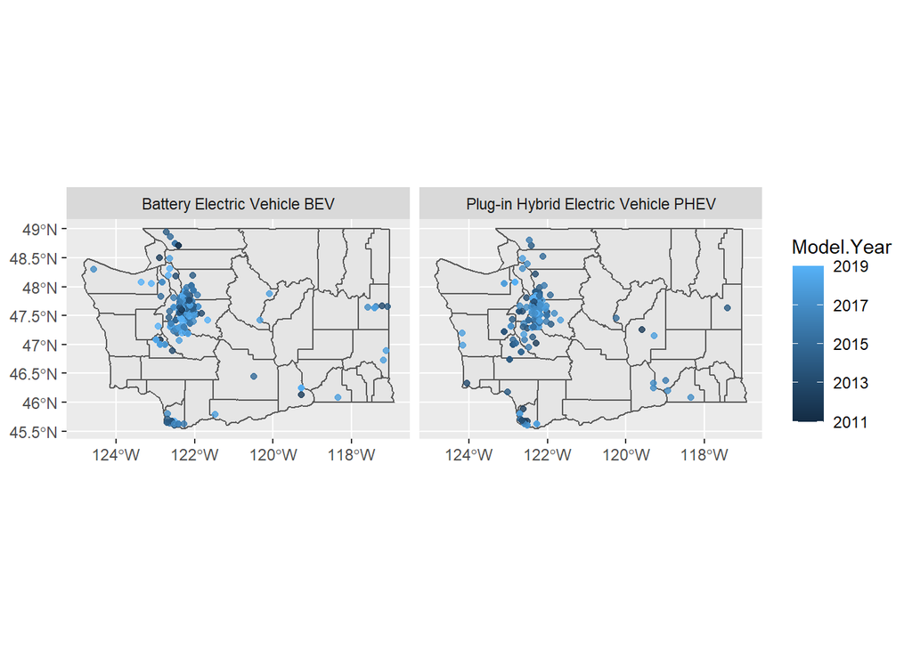

```r
#random subset of 500 points plotted based on electric vehicle type and color coded by year
ggplot()+
  geom_sf(data=counties)+
  #the sample function is what samples 500 points from the csv file cleaned via the filter function (which is now the df_sf_sub variable)
  geom_sf(data=df_sf_sub[sample(1:nrow(df_sf_sub),500),],
          alpha = 0.8,
          aes(color=Model.Year))+
  #alpha sets the transparency of the points and the aes() function sets the color scale to correspond with the model year field. Since the data is continuous, the colors follow a gradient.
  #facet_wrap() is used to organize the visualization into separate grids according to a variable in the table. This created two different visualizations of randomized 500 points from the CSV file according to electric vehicle type (plug-in hybrid or battery electric)
  facet_wrap(vars(Electric.Vehicle.Type))
```

## Animating the data

This code will create 13 different PNG files (corresponding to the 13 different model years in the CSV file) that can then be compiled to create a gif. The gif would should the accumlation of owners in Washington state over time, as well as how ownership has proliferated across space. Setting transition length to 0 avoids creating PNGS of points moving locations over the years. The warning shown below of no renderer available is of no concern because R Studio will create the PNGs in the same location where the R file has been saved.

```r
anmap <- ggplot()+
  geom_sf(data=counties)+
  geom_sf(data=df_sf_sub, size = 0.5, alpha = 0.5, aes(color=Model.Year))+
  transition_states(Model.Year, transition_length = 0) +
  shadow_mark()

anmap
```

```
## Warning: No renderer available. Please install the gifski, av, or magick package
## to create animated output
```